# ACT_KNN_JosueGomez

Explanation of the intuition behind the KNN algorithm.

The k-NN algorithm, which stands for "k-nearest neighbors," is a supervised learning algorithm used for classification and regression. The intuition behind this algorithm is quite simple and is based on the idea that similar objects tend to be in the same class or have similar output values in a multidimensional space.

KNN algorithm pseudocode

1. Stores the data points and their corresponding labels in the training set.
1. When a new data point is presented, it calculates the distance between this point and all training points. You can use various distance metrics, such as Euclidean distance or Manhattan distance.
2. Identifies the k training points closest to the new point based on the calculated distances.
3. Determine the most common class among these k nearest neighbors. In other words, it counts the neighbors' labels and selects the most frequent label as the prediction for the new data point.

Code Implementation

```python
from google.colab import drive
drive.mount('/content/drive')
import pandas as pd
from sklearn.neighbors import KNeighborsClassifier
from sklearn.model_selection import train_test_split
from sklearn.preprocessing import LabelEncoder
import numpy as np
import matplotlib.pyplot as plt
from sklearn.metrics import accuracy_score
from matplotlib.colors import ListedColormap
```

```python
df = "/content/drive/MyDrive/archive/sensor_readings_2.csv"
data_set = pd.read_csv(df)
data_set.columns = ["SD_Front", "SD_Left", "Classes"]
data_set
```

|  | SD_Front | SD_Left | Classes |
| --- | --- | --- | --- |
| 0 | 1.687 | 0.449 | Slight-Right-Turn |
| 1 | 1.687 | 0.449 | Slight-Right-Turn |
| 2 | 1.687 | 0.449 | Slight-Right-Turn |
| 3 | 1.687 | 0.449 | Slight-Right-Turn |
| 4 | 1.686 | 0.446 | Slight-Right-Turn |
| ... | ... | ... | ... |
| 5450 | 1.024 | 0.657 | Move-Forward |
| 5451 | 0.894 | 0.649 | Sharp-Right-Turn |
| 5452 | 0.873 | 0.642 | Sharp-Right-Turn |
| 5453 | 0.967 | 0.635 | Move-Forward |
| 5454 | 0.854 | 0.628 | Sharp-Right-Turn |

5455 rows × 3 columns

```
Precisión del modelo k-NN: 0.9825847846012832
```

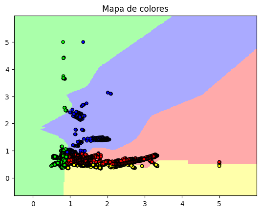

```python
# Dividir los datos en características (X) y etiquetas (Y)
X = data_set.iloc[:, 0:2].values
Y = data_set.iloc[:, 2].values

labelencoder_Y1 = LabelEncoder()
Y = Y.reshape(-1, 1)
Y[:, -1] = labelencoder_Y1.fit_transform(Y[:, -1])
Y = Y.astype(np.float32)

# Dividir los datos en conjuntos de entrenamiento y prueba
X_train, X_test, y_train, y_test = train_test_split(X, Y, test_size=0.2, random_state=42)

# Crear un clasificador k-NN con 5 vecinos (cambiar a 4 para 4 clases)
classifier = KNeighborsClassifier(n_neighbors=5)

# Entrenar el modelo con los datos de entrenamiento
classifier.fit(X_train, y_train)

# Realizar predicciones en el conjunto de prueba
predictions = classifier.predict(X_test)

# Calcular la precisión del modelo
accuracy = accuracy_score(y_test, predictions)
print("Precisión del modelo k-NN:", accuracy)

# Crear un mapa de color
h = .02  # Tamaño de paso en la malla
x_min, x_max = X[:, 0].min() - 1, X[:, 0].max() + 1
y_min, y_max = X[:, 1].min() - 1, X[:, 1].max() + 1
xx, yy = np.meshgrid(np.arange(x_min, x_max, h), np.arange(y_min, y_max, h))

# Predecir la clase para cada punto en la malla
Z = classifier.predict(np.c_[xx.ravel(), yy.ravel()])
Z = Z.reshape(xx.shape)

# Crear un mapa de colores
cmap_light = ListedColormap(['#FFAAAA', '#AAFFAA', '#AAAAFF', '#FFFFAA'])
cmap_bold = ListedColormap(['#FF0000', '#00FF00', '#0000FF', '#FFFF00'])

# Graficar el mapa de colores
plt.figure()
plt.pcolormesh(xx, yy, Z, cmap=cmap_light)

# Graficar los puntos de datos
plt.scatter(X[:, 0], X[:, 1], c=Y, cmap=cmap_bold, edgecolor='k', s=20)
plt.xlim(xx.min(), xx.max())
plt.ylim(yy.min(), yy.max())
plt.title("Mapa de colores")
plt.show()
```

1. Red (#FF0000): Class 0
2. Green (#00FF00): Class 1
3. Blue (#0000FF): Class 2
4. Yellow (#FFFF00): Class 3

Loss function + Optimization function identification

In the context of the k-NN algorithm, there is no loss function or optimization function that is optimized during model training. This is because k-NN is an instance-based algorithm and has no internal parameters that are optimized during the training process.

Instead of having an explicit optimization process, k-NN simply stores all the training data and, when a new instance is presented for prediction, finds the k nearest neighbors and makes a decision based on the classes of those neighbors ( in the case of classification) or in their output values (in the case of regression).